# Project: Investigate The Movie Database (TMDb)

- Introduction
- Data Wrangling
- Exploratory Data Analysis
- Conclusions

## 1. Introduction

### - 1.1 Data Description

The dataset comprises 10866 movies across 21 columns, the first 2 columns are basically IDs for the movies and the remaining 19 are typical variables descriping each entry. Worth mentioning that the data encompasses 56 years form 1960 to 2015.

[output not shown]

### - 1.2 Problem Statemen

Given such information-rich dataset, some of the question that deserve answering are:

1. Top ten movies in terms of (revenues, budget, Average votes, popularity).
2. What are the geners of movies generating the highest revenue?
3. What are the geners of movies consuming the highest budgets?
4. What are geners of movies recieving the highest vote score?
5. Film aficionados might have different interests. How have the general taste and preferences changed over years?
6. Given that major films costing over 100 million to produce can still flop, this question is more important than ever to the industry.

```python
# setting up import statements for all of the packages to use

import pandas as pd
import numpy as np
import matplotlib.pyplot as plt
import seaborn as sns
%matplotlib inline
```

## Data Wrangling

### General Properties

```python
# Loading data and printing out a few lines to inspect data
df = pd.read_csv('tmdb-movies.csv', index_col='id')
#Exploring first few rows
df.head(5)
```

| id | imdb_id | popularity | budget | revenue | original_title | cast | homepage | director | tagline | keywords | overview | runtime | genres | production_companies | release_date | vote_count | vote_average | release_year | budget_adj | revenue_adj |
| --- | --- | --- | --- | --- | --- | --- | --- | --- | --- | --- | --- | --- | --- | --- | --- | --- | --- | --- | --- | --- |
| 135397 | tt0369610 | 32.985763 | 150000000 | 1513528810 | Jurassic World | Chris Pratt\|Bryce Dallas Howard\|Irrfan Khan\|Vi... | http://www.jurassicworld.com/ | Colin Trevorrow | The park is open. | monster\|dna\|tyrannosaurus rex\|velociraptor\|island | Twenty-two years after the events of Jurassic ... | 124 | Action\|Adventure\|Science Fiction\|Thriller | Universal Studios\|Amblin Entertainment\|Legenda... | 6/9/15 | 5562 | 6.5 | 2015 | 1.379999e+08 | 1.392446e+09 |
| 76341 | tt1392190 | 28.419936 | 150000000 | 378436354 | Mad Max: Fury Road | Tom Hardy\|Charlize Theron\|Hugh Keays-Byrne\|Nic... | http://www.madmaxmovie.com/ | George Miller | What a Lovely Day. | future\|chase\|post-apocalyptic\|dystopia\|australia | An apocalyptic story set in the furthest reach... | 120 | Action\|Adventure\|Science Fiction\|Thriller | Village Roadshow Pictures\|Kennedy Miller Produ... | 5/13/15 | 6185 | 7.1 | 2015 | 1.379999e+08 | 3.481613e+08 |
| 262500 | tt2908446 | 13.112507 | 110000000 | 295238201 | Insurgent | Shailene Woodley\|Theo James\|Kate Winslet\|Ansel... | http://www.thedivergentseries.movie/#insurgent | Robert Schwentke | One Choice Can Destroy You | based on novel\|revolution\|dystopia\|sequel\|dyst... | Beatrice Prior must confront her inner demons ... | 119 | Adventure\|Science Fiction\|Thriller | Summit Entertainment\|Mandeville Films\|Red Wago... | 3/18/15 | 2480 | 6.3 | 2015 | 1.012000e+08 | 2.716190e+08 |
| 140607 | tt2488496 | 11.173104 | 200000000 | 2068178225 | Star Wars: The Force Awakens | Harrison Ford\|Mark Hamill\|Carrie Fisher\|Adam D... | http://www.starwars.com/films/star-wars-episod... | J.J. Abrams | Every generation has a story. | android\|spaceship\|jedi\|space opera\|3d | Thirty years after defeating the Galactic Empi... | 136 | Action\|Adventure\|Science Fiction\|Fantasy | Lucasfilm\|Truenorth Productions\|Bad Robot | 12/15/15 | 5292 | 7.5 | 2015 | 1.839999e+08 | 1.902723e+09 |
| 168259 | tt2820852 | 9.335014 | 190000000 | 1506249360 | Furious 7 | Vin Diesel\|Paul Walker\|Jason Statham\|Michelle ... | http://www.furious7.com/ | James Wan | Vengeance Hits Home | car race\|speed\|revenge\|suspense\|car | Deckard Shaw seeks revenge against Dominic Tor... | 137 | Action\|Crime\|Thriller | Universal Pictures\|Original Film\|Media Rights ... | 4/1/15 | 2947 | 7.3 | 2015 | 1.747999e+08 | 1.385749e+09 |

```python
#  Type and look for instances of missing or possibly errant data.
df.info()
```

```
<class 'pandas.core.frame.DataFrame'>
Int64Index: 10866 entries, 135397 to 22293
Data columns (total 20 columns):
imdb_id                 10856 non-null object
popularity              10866 non-null float64
budget                  10866 non-null int64
revenue                 10866 non-null int64
original_title          10866 non-null object
cast                    10790 non-null object
homepage                2936 non-null object
director                10822 non-null object
tagline                 8042 non-null object
keywords                9373 non-null object
overview                10862 non-null object
runtime                 10866 non-null int64
genres                  10843 non-null object
production_companies    9836 non-null object
release_date            10866 non-null object
vote_count              10866 non-null int64
vote_average            10866 non-null float64
release_year            10866 non-null int64
budget_adj              10866 non-null float64
revenue_adj             10866 non-null float64
dtypes: float64(4), int64(5), object(11)
memory usage: 1.7+ MB
```

```python
# Checking for duplicates
df.duplicated().sum()
```

```
1
```

```python
# checking for null-values
df.isnull().sum()
```

```
imdb_id                   10
popularity                 0
budget                     0
revenue                    0
original_title             0
cast                      76
homepage                7930
director                  44
tagline                 2824
keywords                1493
overview                   4
runtime                    0
genres                    23
production_companies    1030
release_date               0
vote_count                 0
vote_average               0
release_year               0
budget_adj                 0
revenue_adj                0
dtype: int64
```

```python
# Investigating the tagline content and significance
df.tagline.head()
```

```
id
135397                The park is open.
76341                What a Lovely Day.
262500       One Choice Can Destroy You
140607    Every generation has a story.
168259              Vengeance Hits Home
Name: tagline, dtype: object
```

```python
# Building intuition about the different numerical variables of the dataset.
df.describe()
```

|  | popularity | budget | revenue | runtime | vote_count | vote_average | release_year | budget_adj | revenue_adj |
| --- | --- | --- | --- | --- | --- | --- | --- | --- | --- |
| count | 10866.000000 | 1.086600e+04 | 1.086600e+04 | 10866.000000 | 10866.000000 | 10866.000000 | 10866.000000 | 1.086600e+04 | 1.086600e+04 |
| mean | 0.646441 | 1.462570e+07 | 3.982332e+07 | 102.070863 | 217.389748 | 5.974922 | 2001.322658 | 1.755104e+07 | 5.136436e+07 |
| std | 1.000185 | 3.091321e+07 | 1.170035e+08 | 31.381405 | 575.619058 | 0.935142 | 12.812941 | 3.430616e+07 | 1.446325e+08 |
| min | 0.000065 | 0.000000e+00 | 0.000000e+00 | 0.000000 | 10.000000 | 1.500000 | 1960.000000 | 0.000000e+00 | 0.000000e+00 |
| 25% | 0.207583 | 0.000000e+00 | 0.000000e+00 | 90.000000 | 17.000000 | 5.400000 | 1995.000000 | 0.000000e+00 | 0.000000e+00 |
| 50% | 0.383856 | 0.000000e+00 | 0.000000e+00 | 99.000000 | 38.000000 | 6.000000 | 2006.000000 | 0.000000e+00 | 0.000000e+00 |
| 75% | 0.713817 | 1.500000e+07 | 2.400000e+07 | 111.000000 | 145.750000 | 6.600000 | 2011.000000 | 2.085325e+07 | 3.369710e+07 |
| max | 32.985763 | 4.250000e+08 | 2.781506e+09 | 900.000000 | 9767.000000 | 9.200000 | 2015.000000 | 4.250000e+08 | 2.827124e+09 |

A salient remark is that around 50% of our dataset movies have 0 budget and 0 revenue. An issue that should be considered when trying to glean insight for the financial figures.

```python
# Investigating the movies with zero budget and their count
zero_budget = df[df['budget_adj'] == 0]
zero_budget.budget_adj.value_counts()
```

```
0.0    5696
Name: budget_adj, dtype: int64
```

From running the previous few line of codes the following issues are noticed:

- There's only one duplicated row.
- The column "homepage" has most of its values as null.
- The budget and revenue columns are adjusted later with the **budget_adj and revenue_adj columns**.
- The genres' entries pose a structural challenge to perform analyses on the individual genre level as there're many incidents of multiple genres per movie; the same applies for the cast and director columns.
- The tagline and overview columns are not relevant to the insights we aim at gleaning.
- Around 50% of the movies have 0 budgets and 0 revenues that have to be dealt with when analysing financial information.

```python
#Dropping the duplicate row
df.drop_duplicates(inplace=True)
```

Taking into concideration the following points:

- The column "homepage" has most of its values as null.
- The budget and revenue columns are adjusted as per the budget_adj and revenue_adj columns.
- The tagline, overview, keywords columns will not be utilized in the analysis.

Building on the aforementioned, deleting those columns will not impact our anlysis.

```python
# Drop cloumns of no use
df.drop(['budget', 'revenue', 'homepage', 'tagline', 'overview', 'keywords'], axis=1, inplace=True)
# Verifying successful columns' removal
df.columns
```

```
Index(['imdb_id', 'popularity', 'original_title', 'cast', 'director',
       'runtime', 'genres', 'production_companies', 'release_date',
       'vote_count', 'vote_average', 'release_year', 'budget_adj',
       'revenue_adj'],
      dtype='object')
```

```python
#Exploring generes entries
df.genres.value_counts().head(10)
```

```
Drama                   712
Comedy                  712
Documentary             312
Drama|Romance           289
Comedy|Drama            280
Comedy|Romance          268
Horror|Thriller         259
Horror                  253
Comedy|Drama|Romance    222
Drama|Thriller          138
Name: genres, dtype: int64
```

As per the previous sample of genres' entries, there's a challenge to perform analyses on the individual genre level. In order to do such analyses, the genres have to be separated. To do that, i opted to construct separate dataframe for genres and movie ids to use through the analysis.

```python
# First splitting the multiple genres entries into separate columns.
genres_df = df['genres'].str.split("|", expand=True)

# Verifying successful separation
genres_df.head(3)
```

| id | 0 | 1 | 2 | 3 | 4 |
| --- | --- | --- | --- | --- | --- |
| 135397 | Action | Adventure | Science Fiction | Thriller | None |
| 76341 | Action | Adventure | Science Fiction | Thriller | None |
| 262500 | Adventure | Science Fiction | Thriller | None | None |

```python
# Creating a separate dataframe form unique genres records.
genres_df = genres_df.stack()
genres_df = pd.DataFrame(genres_df)
genres_df.head()
```

| id |  | 0 |
| --- | --- | --- |
| 135397 | 0 | Action |
|  | 1 | Adventure |
|  | 2 | Science Fiction |
|  | 3 | Thriller |
| 76341 | 0 | Action |

```python
#Renaming the genres column and verifying the genres value count
genres_df.rename(columns={0:'genres_adj'}, inplace=True)
genres_df.genres_adj.value_counts()
```

```
Drama              4760
Comedy             3793
Thriller           2907
Action             2384
Romance            1712
Horror             1637
Adventure          1471
Crime              1354
Family             1231
Science Fiction    1229
Fantasy             916
Mystery             810
Animation           699
Documentary         520
Music               408
History             334
War                 270
Foreign             188
TV Movie            167
Western             165
Name: genres_adj, dtype: int64
```

## Exploratory Data Analysis

### Top ten movies in terms of (revenues, vote average, budget, popularity ), do they seem related?

```python
# Top ten revenue movies
df.nlargest(10, 'revenue_adj').original_title
```

```
id
19995                             Avatar
11                             Star Wars
597                              Titanic
9552                        The Exorcist
578                                 Jaws
140607      Star Wars: The Force Awakens
601           E.T. the Extra-Terrestrial
1642                             The Net
12230     One Hundred and One Dalmatians
24428                       The Avengers
Name: original_title, dtype: object
```

```python
# Top ten vote average movies
df.nlargest(10, 'vote_average').original_title
```

```
id
125336                        The Story of Film: An Odyssey
224972                                 The Mask You Live In
374430                        Black Mirror: White Christmas
51299                                           Life Cycles
24970                                     Pink Floyd: Pulse
45644       Opeth: In Live Concert At The Royal Albert Hall
20313     John Mayer: Where the Light Is Live in Los Ang...
68450                                     The Art of Flight
282848                   Doctor Who: The Time of the Doctor
55676     A Personal Journey with Martin Scorsese Throug...
Name: original_title, dtype: object
```

```python
# Top ten budget movies
df.nlargest(10, 'budget_adj').original_title
```

```
id
46528                              The Warrior's Way
1865     Pirates of the Caribbean: On Stranger Tides
285         Pirates of the Caribbean: At World's End
1452                                Superman Returns
597                                          Titanic
559                                     Spider-Man 3
38757                                        Tangled
99861                        Avengers: Age of Ultron
767           Harry Potter and the Half-Blood Prince
9804                                      Waterworld
Name: original_title, dtype: object
```

```python
# Top ten popularity movies
df.nlargest(10, 'popularity').original_title
```

```
id
135397                           Jurassic World
76341                        Mad Max: Fury Road
157336                             Interstellar
118340                  Guardians of the Galaxy
262500                                Insurgent
100402      Captain America: The Winter Soldier
11                                    Star Wars
245891                                John Wick
140607             Star Wars: The Force Awakens
131631    The Hunger Games: Mockingjay - Part 1
Name: original_title, dtype: object
```

From the previous 4 illustrations of the top tens, it became evident that there's no direct relationship between the budget of a movie and its realized revenues, as well as its popularity and vote average seem not to be impacted by these factors.

To elborate more on the existence of some sort of correlation or the lack thereof, the following set of scatter plots between the various numeric variables of our dataset will make it clear.

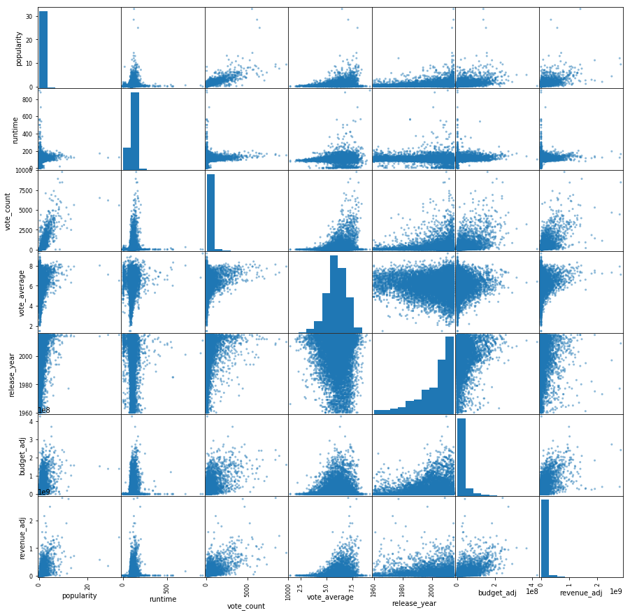

```python
pd.plotting.scatter_matrix(df, figsize=(15,15));
```

### What are the geners of movies generating the highest revenue?

```python
# Merging the genres_df with the orignal dataframe to extract the intended insight about individual genres.
df_merged_1 = df.merge(genres_df,left_index=True, right_index=True)
df_merged_1.head()
```

| id |  | imdb_id | popularity | original_title | cast | director | runtime | genres | production_companies | release_date | vote_count | vote_average | release_year | budget_adj | revenue_adj | genres_adj |
| --- | --- | --- | --- | --- | --- | --- | --- | --- | --- | --- | --- | --- | --- | --- | --- | --- |
| 135397 | 0 | tt0369610 | 32.985763 | Jurassic World | Chris Pratt\|Bryce Dallas Howard\|Irrfan Khan\|Vi... | Colin Trevorrow | 124 | Action\|Adventure\|Science Fiction\|Thriller | Universal Studios\|Amblin Entertainment\|Legenda... | 6/9/15 | 5562 | 6.5 | 2015 | 1.379999e+08 | 1.392446e+09 | Action |
|  | 1 | tt0369610 | 32.985763 | Jurassic World | Chris Pratt\|Bryce Dallas Howard\|Irrfan Khan\|Vi... | Colin Trevorrow | 124 | Action\|Adventure\|Science Fiction\|Thriller | Universal Studios\|Amblin Entertainment\|Legenda... | 6/9/15 | 5562 | 6.5 | 2015 | 1.379999e+08 | 1.392446e+09 | Adventure |
|  | 2 | tt0369610 | 32.985763 | Jurassic World | Chris Pratt\|Bryce Dallas Howard\|Irrfan Khan\|Vi... | Colin Trevorrow | 124 | Action\|Adventure\|Science Fiction\|Thriller | Universal Studios\|Amblin Entertainment\|Legenda... | 6/9/15 | 5562 | 6.5 | 2015 | 1.379999e+08 | 1.392446e+09 | Science Fiction |
|  | 3 | tt0369610 | 32.985763 | Jurassic World | Chris Pratt\|Bryce Dallas Howard\|Irrfan Khan\|Vi... | Colin Trevorrow | 124 | Action\|Adventure\|Science Fiction\|Thriller | Universal Studios\|Amblin Entertainment\|Legenda... | 6/9/15 | 5562 | 6.5 | 2015 | 1.379999e+08 | 1.392446e+09 | Thriller |
| 76341 | 0 | tt1392190 | 28.419936 | Mad Max: Fury Road | Tom Hardy\|Charlize Theron\|Hugh Keays-Byrne\|Nic... | George Miller | 120 | Action\|Adventure\|Science Fiction\|Thriller | Village Roadshow Pictures\|Kennedy Miller Produ... | 5/13/15 | 6185 | 7.1 | 2015 | 1.379999e+08 | 3.481613e+08 | Action |

```python
# Droping the original genres column that contains multiple entries
df_merged_1.drop('genres', axis=1, inplace=True)
```

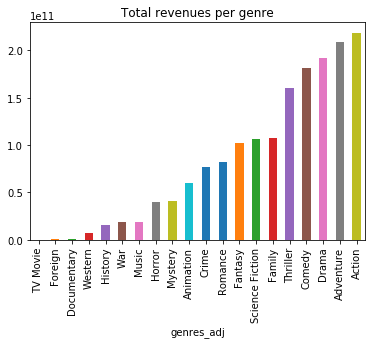

```python
# Which genres generating the highest revenues
df_merged_1.groupby('genres_adj').revenue_adj.sum().sort_values().plot(kind='bar', title=('Total revenues per genre'), );
```

### What are the geners of movies consuming the highest budgets?

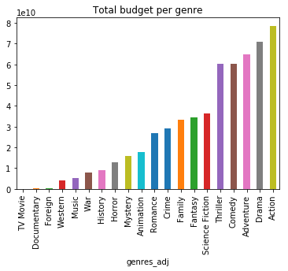

```python
df_merged_1.groupby('genres_adj').budget_adj.sum().sort_values().plot(kind='bar', title=('Total budget per genre'));
```

It's clear that Action, Adventure, Drame and comedy are the genres generating most revenues and consuming most budgets.

### What are geners of movies recieving the highest vote score?

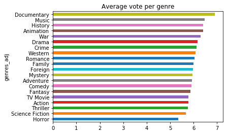

```python
df_merged_1.groupby('genres_adj').vote_average.mean().sort_values().plot(kind='barh', title=('Average vote per genre'));
```

On the vote avarage score, Documentary, music, history and animation are receiving the highest average vote average.

### How have the general taste and preferences changed over years?

```python
#creating a decade column
bin_edges = [1960,1970,1980,1990,2000,2010,2020]
bin_names = ['60s','70s','80s','90s','00s','10s']
df_merged_1['decade']=pd.cut(df_merged_1['release_year'], bin_edges, labels=bin_names)
df_merged_1.head(2)
```

| id |  | imdb_id | popularity | original_title | cast | director | runtime | production_companies | release_date | vote_count | vote_average | release_year | budget_adj | revenue_adj | genres_adj | decade |
| --- | --- | --- | --- | --- | --- | --- | --- | --- | --- | --- | --- | --- | --- | --- | --- | --- |
| 135397 | 0 | tt0369610 | 32.985763 | Jurassic World | Chris Pratt\|Bryce Dallas Howard\|Irrfan Khan\|Vi... | Colin Trevorrow | 124 | Universal Studios\|Amblin Entertainment\|Legenda... | 6/9/15 | 5562 | 6.5 | 2015 | 1.379999e+08 | 1.392446e+09 | Action | 10s |
|  | 1 | tt0369610 | 32.985763 | Jurassic World | Chris Pratt\|Bryce Dallas Howard\|Irrfan Khan\|Vi... | Colin Trevorrow | 124 | Universal Studios\|Amblin Entertainment\|Legenda... | 6/9/15 | 5562 | 6.5 | 2015 | 1.379999e+08 | 1.392446e+09 | Adventure | 10s |

```python
# Grouping the dataframe by decade and genres and calculating the sum of popularity for each genre across decades
df_decade = df_merged_1.groupby(['decade','genres_adj']).popularity.sum()
# Checking for grouping
df_decade.head(25)
```

```
decade  genres_adj
60s     Action             39.170788
        Adventure          47.387600
        Animation          14.798290
        Comedy             48.432183
        Crime              20.927297
        Documentary         0.816658
        Drama              66.291582
        Family             24.583369
        Fantasy             8.355288
        Foreign             2.024728
        History            12.189804
        Horror             11.998184
        Music              11.158157
        Mystery            16.702666
        Romance            24.441167
        Science Fiction    13.326122
        TV Movie            1.448110
        Thriller           34.265184
        War                14.753694
        Western            11.463554
70s     Action             86.550940
        Adventure          68.038885
        Animation           9.044243
        Comedy             58.192285
        Crime              47.179225
Name: popularity, dtype: float64
```

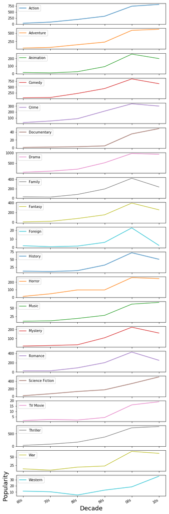

```python
# Plotting the progress of popularity for each genre across decades

df_decade.unstack(level=1).plot(kind='line', subplots=True , figsize=(8,30));
plt.xlabel('Decade', fontsize = 18)
plt.ylabel('Popularity', fontsize = 18)
plt.xticks([0,1,2,3,4,5], ['60s','70s','80s','90s','00s','10s']);
```

The progress of popularity for Drama, Action, Adventure and comedy have been rising dramatically across decade, the matter that can be elaborated by plotting a collective line graph as follows.

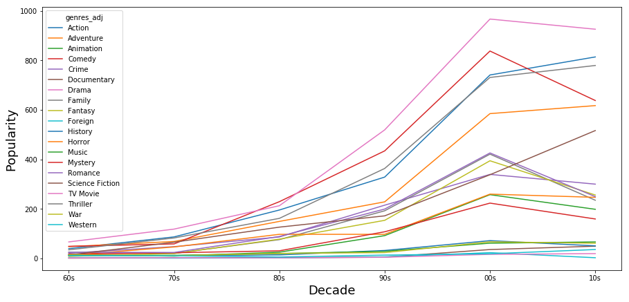

```python
# Plotting the progress of popularity for all genres across decades

df_decade.unstack(level=1).plot(kind='line', subplots=False , figsize=(15,7));
plt.xlabel('Decade', fontsize = 18)
plt.ylabel('Popularity', fontsize = 18)
plt.xticks([0,1,2,3,4,5], ['60s','70s','80s','90s','00s','10s']);
```

## Financial insights

As alluded in the introduction, we have almost half of the movies with zero budgets and zero revenues that might be a problem with the data collection or entry. So in counting for the financial figures, it is prudent to limit our analysis to the entries with positive budgets or revenues.

```python
# Detrmining the non_zero movies for budgets and revenues
non_zero_movies = pd.DataFrame(df.query('revenue_adj > 0 and budget_adj > 0'))
non_zero_movies['profit_loss'] = non_zero_movies['revenue_adj'] - non_zero_movies['budget_adj']

# Total count of non_zero_budget movies
non_zero_movies.shape[0]
```

```
3854
```

```python
# Count of movies realising loss

non_zero_movies.query('profit_loss < 0')['original_title'].count()
```

```
1072
```

```python
# % of losing movies
non_zero_movies.query('profit_loss < 0')['original_title'].count() / non_zero_movies.shape[0]
```

```
0.27815256875973016
```

So there is 3854 movies with positive budgets and revenues, 1072 of them recording loss which accounts for nearly 28% of the total movies.

### Given that major films costing over 100 million to produce can still flop, this question is more important than ever to the industry.

```python
high_budget =pd.DataFrame(df.query('budget_adj >= 100000000 and revenue_adj > 0'))
high_budget['profit_loss'] = high_budget['revenue_adj'] - high_budget['budget_adj']
high_budget.shape
```

```
(417, 15)
```

```python
# % of High budget from non_zero_budget movies
high_budget.shape[0] / non_zero_movies.shape[0]
```

```
0.10819927348209653
```

```python
# Total count of films of budget equal to or more than 100 million.
total = high_budget.shape[0]
total
```

```
417
```

```python
# Count of losing movies from the high budget films
high_budget.query('profit_loss < 0')['original_title'].count()
```

```
60
```

```python
# % of losing movies with High budget.
high_budget.query('profit_loss < 0')['original_title'].count() / total
```

```
0.14388489208633093
```

From the above statistics, around 11% of the non zero budget and revenue movies are of budget over 100 million dollars, and 14% of those high budget movies recorded losses.

## Conclusions

In summary, the following insights can be gleaned and worth testing for verification in the other reports:

**In Addition** , The dataset had the following limitations:

1. Some of the variables included a great deal of null data that may result into misleading insights when analysed; such as the homepage column that i opted to delete.
2. The zero budget and zero revenues values of almost 65% of the movies included in the dataset poses additional challenges when analysing the financial performance of the movies as a measure for success.
3. The combined genres' records, director records, cast records requires special treatment to analyse them individually.